# R Bootcamp Einstein 2017

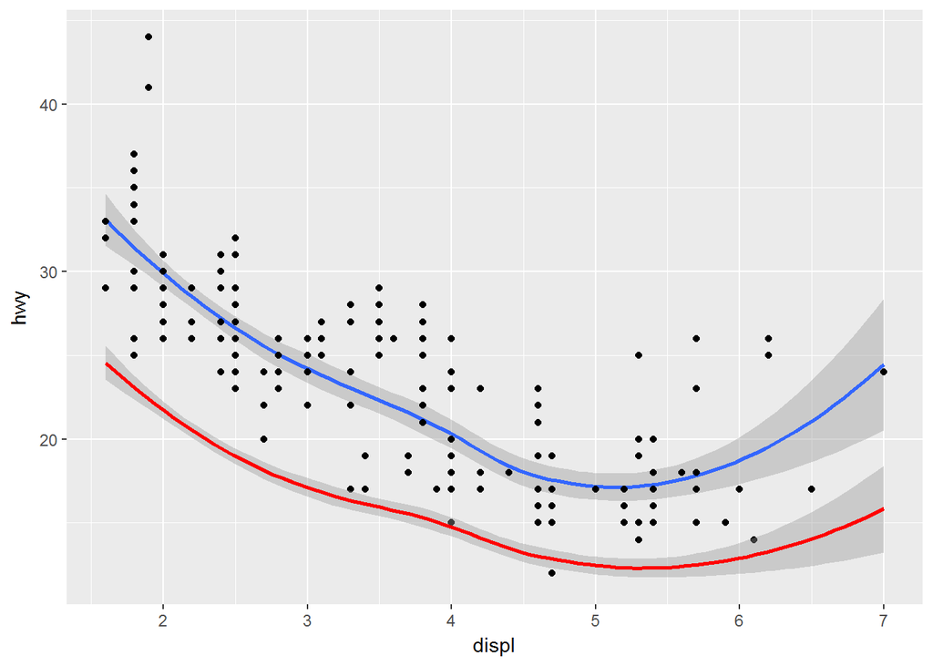

```r
ggplot(data = mpg, mapping = aes(x = displ, y = hwy)) + geom_smooth() + geom_point() +
  geom_smooth(mapping = aes(x = displ,y = cty),color = "red")
```

Note: if you want to plot a variable to a feature like color or size, it must go in the aes() term, if you just want to set them at a certain value they go outside the aes

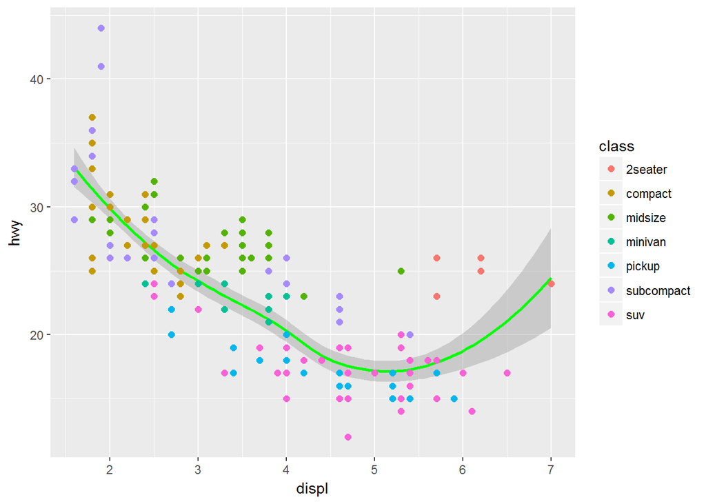

```r
ggplot(mpg, aes(displ,hwy)) + geom_smooth(color = "green") + geom_point(aes(color=class),size=2)
```

You can also split the plot into subplots based on a varible using `facet`

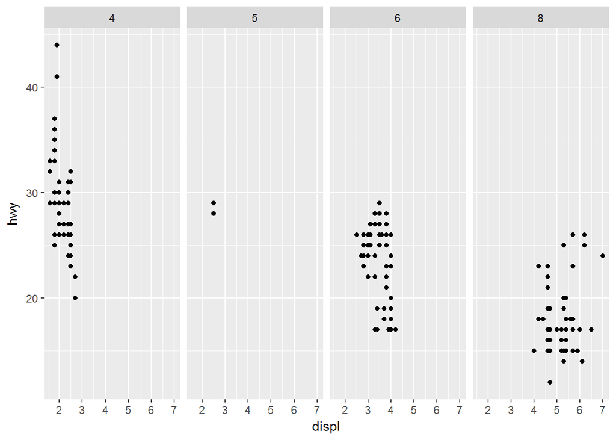

```r
ggplot(mpg, aes(displ,hwy))  + geom_point() + facet_grid(.~cyl)
```

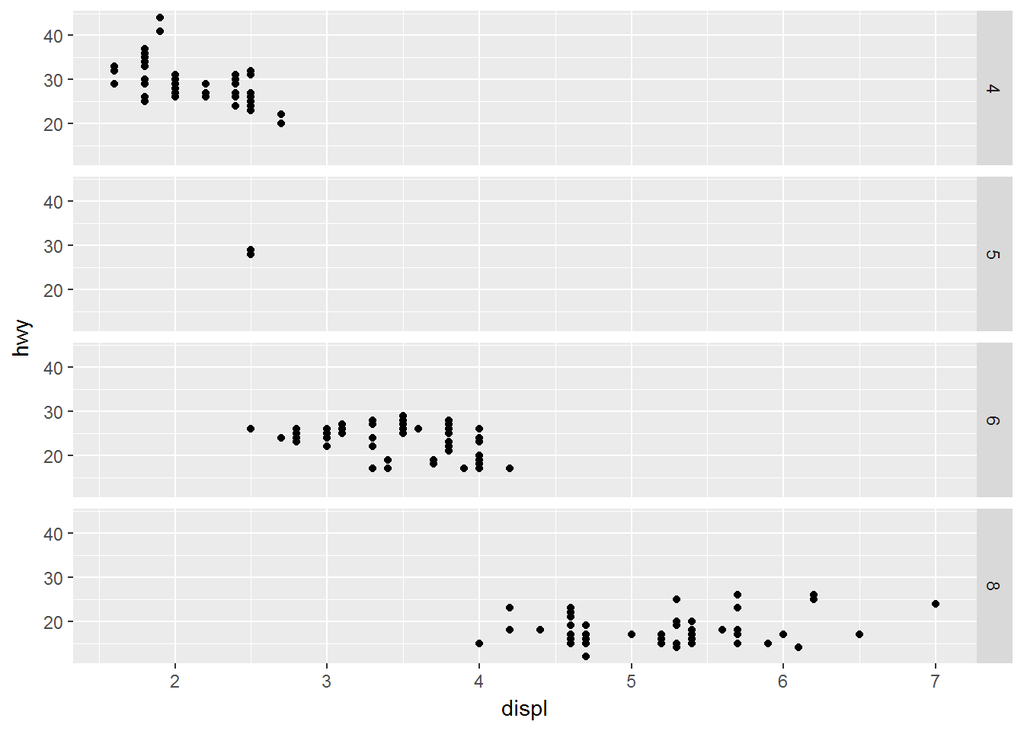

```r
ggplot(mpg, aes(displ,hwy))  + geom_point() + facet_grid(cyl~.)
```

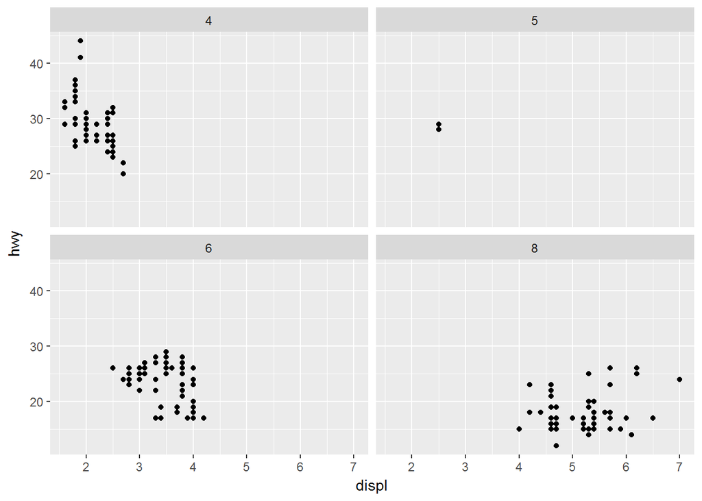

```r
ggplot(mpg, aes(displ,hwy))  + geom_point() + facet_wrap(~cyl)
```

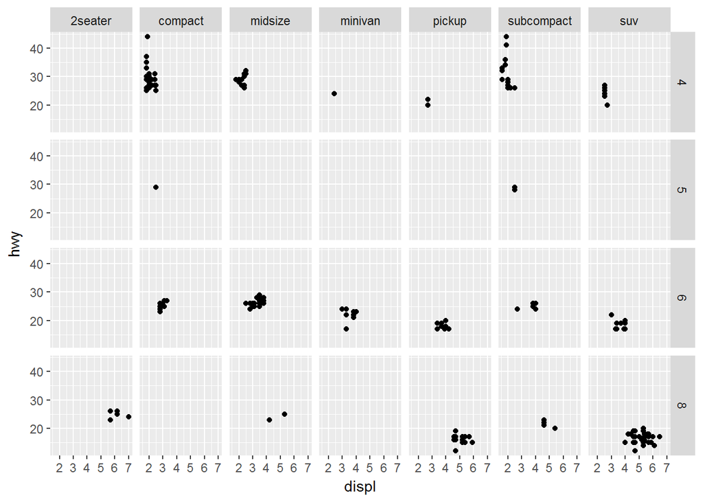

```r
ggplot(mpg, aes(displ,hwy))  + geom_point() + facet_grid(cyl~class)
```

Play with ggplot trying to make some of the following plots:

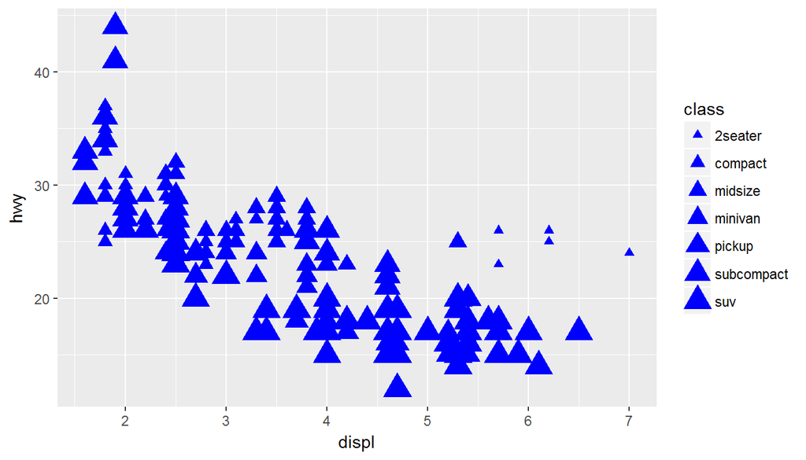

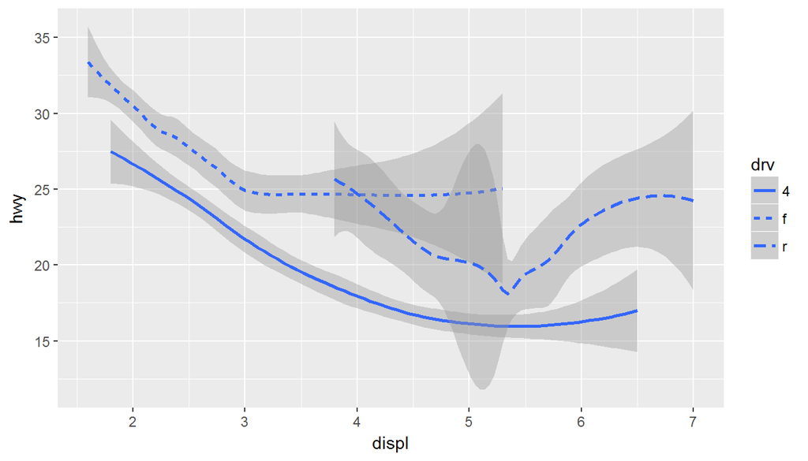

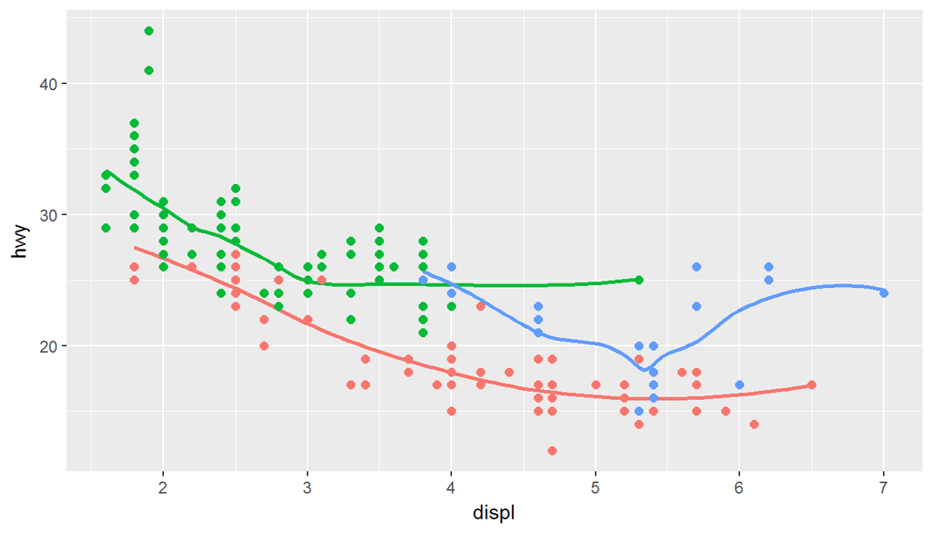

## Graphics and Statistical Transformations

This time we will be using the `diamonds` dataset

```r
summary(diamonds)
```

```
##      carat               cut        color        clarity
##  Min.   :0.2000   Fair     : 1610   D: 6775   SI1    :13065
##  1st Qu.:0.4000   Good     : 4906   E: 9797   VS2    :12258
##  Median :0.7000   Very Good:12082   F: 9542   SI2    : 9194
##  Mean   :0.7979   Premium  :13791   G:11292   VS1    : 8171
##  3rd Qu.:1.0400   Ideal    :21551   H: 8304   VVS2   : 5066
##  Max.   :5.0100                     I: 5422   VVS1   : 3655
##                                     J: 2808   (Other): 2531
##      depth           table           price             x
##  Min.   :43.00   Min.   :43.00   Min.   :  326   Min.   : 0.000
##  1st Qu.:61.00   1st Qu.:56.00   1st Qu.:  950   1st Qu.: 4.710
##  Median :61.80   Median :57.00   Median : 2401   Median : 5.700
##  Mean   :61.75   Mean   :57.46   Mean   : 3933   Mean   : 5.731
##  3rd Qu.:62.50   3rd Qu.:59.00   3rd Qu.: 5324   3rd Qu.: 6.540
##  Max.   :79.00   Max.   :95.00   Max.   :18823   Max.   :10.740
##
##        y                z
##  Min.   : 0.000   Min.   : 0.000
##  1st Qu.: 4.720   1st Qu.: 2.910
##  Median : 5.710   Median : 3.530
##  Mean   : 5.735   Mean   : 3.539
##  3rd Qu.: 6.540   3rd Qu.: 4.040
##  Max.   :58.900   Max.   :31.800
##
```

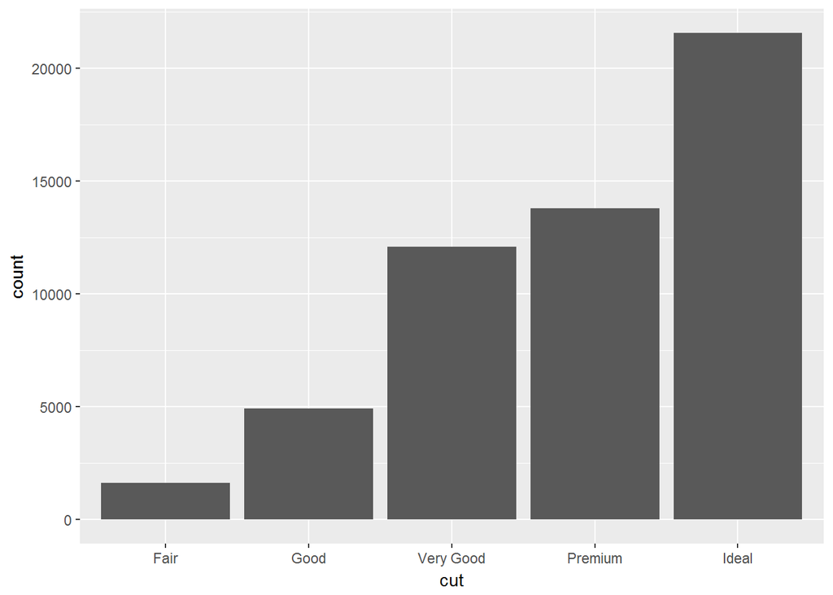

```r
ggplot(diamonds,aes(cut)) + geom_bar()
```

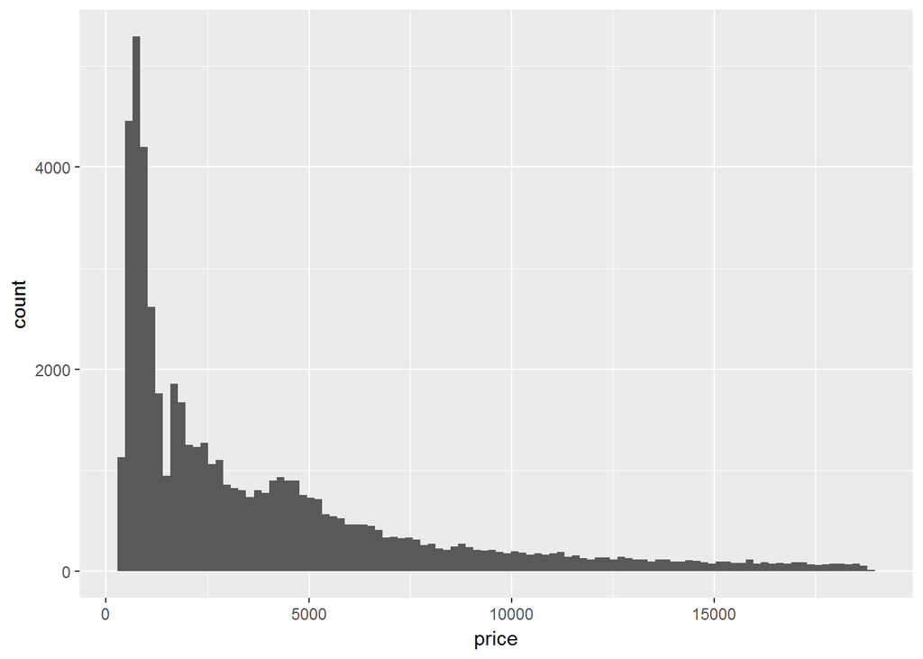

```r
ggplot(diamonds,aes(price)) + geom_histogram(bins=100)
```

Bar charts, histograms and the other plots in the one variable section of the ggplot2 cheat sheet bin your data based on a single variable

You can determine the computed variables of a graphic by using the help function:

- Computed variables
  - count
    - number of points in bin
  - prop
    - groupwise proportion

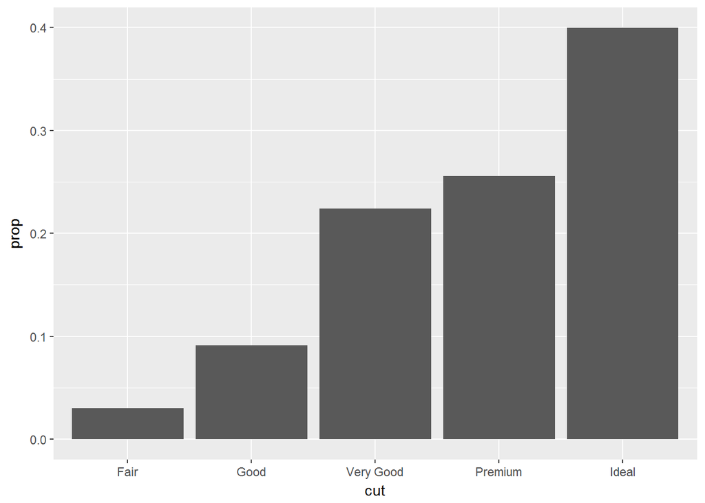

```r
ggplot(diamonds) + geom_bar(aes(x=cut,y=..prop..,group=1))
```

### Position adjustments

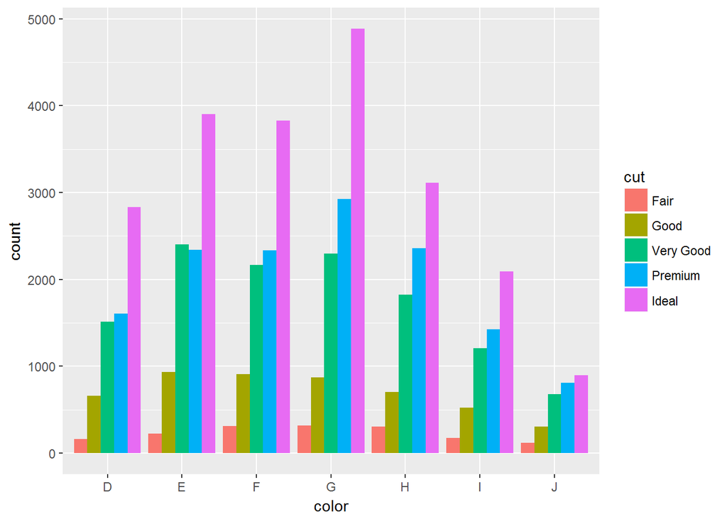

```r
ggplot(diamonds) + geom_bar(aes(x = color, fill = cut), position = "dodge")
```

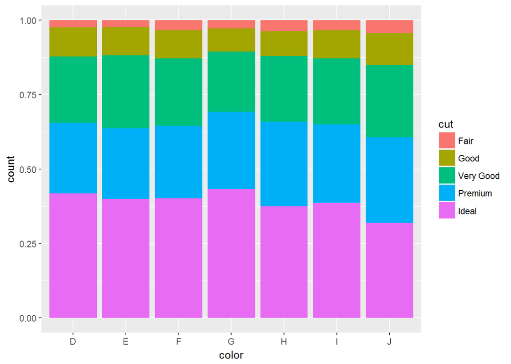

```r
ggplot(diamonds) + geom_bar(aes(x = color, fill = cut), position = "fill")
```

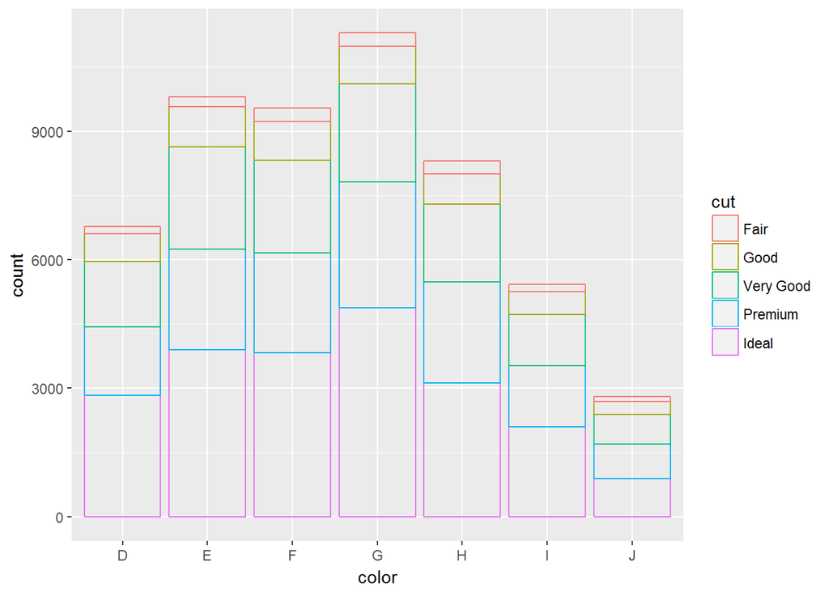

```r
ggplot(diamonds) + geom_bar(aes(x = color, color = cut), position = "stack",fill=NA)
```

## Some more example plots from http://r-statistics.co/Top50-Ggplot2-Visualizations-MasterList-R-Code.html

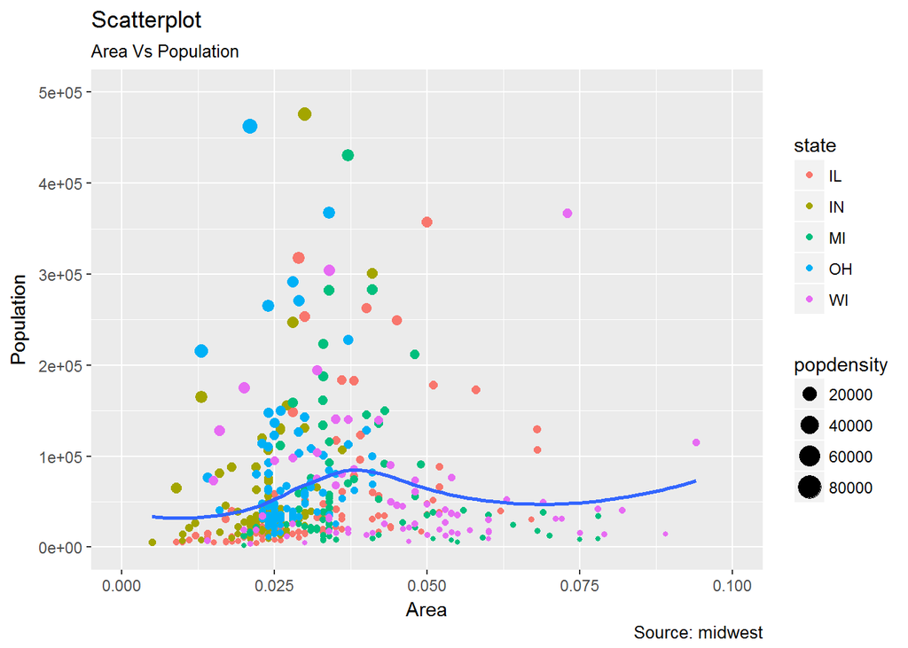

```r
ggplot(midwest, aes(x=area, y=poptotal)) +
  geom_point(aes(col=state, size=popdensity)) +
  geom_smooth(method="loess", se=F) + xlim(c(0, 0.1)) + ylim(c(0, 500000)) +
  labs(subtitle="Area Vs Population", y="Population", x="Area", title="Scatterplot", caption = "Source: midwest")
```

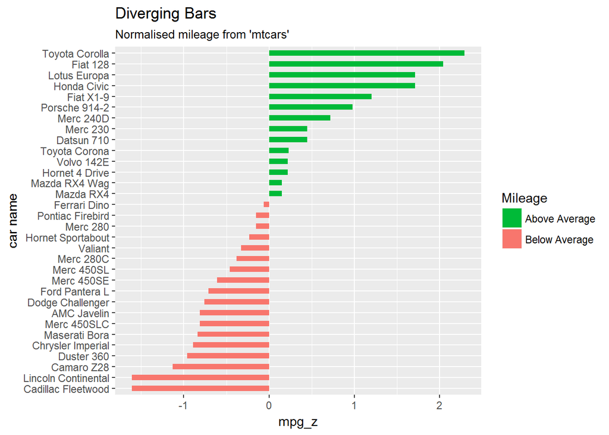

```r
mtcars$`car name` <- rownames(mtcars)  # create new column for car names
mtcars$mpg_z <- round((mtcars$mpg - mean(mtcars$mpg))/sd(mtcars$mpg), 2)  # compute normalized mpg
mtcars$mpg_type <- ifelse(mtcars$mpg_z < 0, "below", "above")  # above / below avg flag
mtcars <- mtcars[order(mtcars$mpg_z), ]  # sort
mtcars$`car name` <- factor(mtcars$`car name`, levels = mtcars$`car name`)  # convert to factor to retain sorted order in plot.

ggplot(mtcars, aes(x=`car name`, y=mpg_z, label=mpg_z)) +
  geom_bar(stat='identity', aes(fill=mpg_type), width=.5)  +
  scale_fill_manual(name="Mileage",
                    labels = c("Above Average", "Below Average"),
                    values = c("above"="#00ba38", "below"="#f8766d")) +
  labs(subtitle="Normalised mileage from 'mtcars'", title= "Diverging Bars") +
  coord_flip()
```

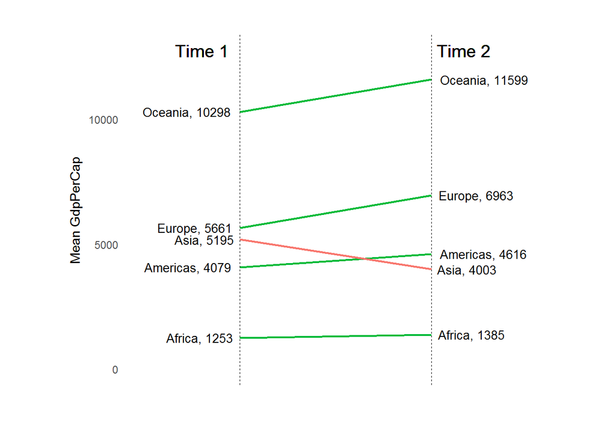

```r
# prep data
df <- read.csv("https://raw.githubusercontent.com/selva86/datasets/master/gdppercap.csv")
colnames(df) <- c("continent", "1952", "1957")
left_label <- paste(df$continent, round(df$`1952`),sep=", ")
right_label <- paste(df$continent, round(df$`1957`),sep=", ")
df$class <- ifelse((df$`1957` - df$`1952`) < 0, "red", "green")

ggplot(df) + geom_segment(aes(x=1, xend=2, y=`1952`, yend=`1957`, col=class), size=.75, show.legend=F) +
  geom_vline(xintercept=1, linetype="dashed", size=.1) +
  geom_vline(xintercept=2, linetype="dashed", size=.1) +
  scale_color_manual(labels = c("Up", "Down"),
                     values = c("green"="#00ba38", "red"="#f8766d")) +  # color of lines
  labs(x="", y="Mean GdpPerCap") +  # Axis labels
  xlim(.5, 2.5) + ylim(0,(1.1*(max(df$`1952`, df$`1957`)))) + # X and Y axis limits
  geom_text(label=left_label, y=df$`1952`, x=rep(1, NROW(df)), hjust=1.1, size=3.5) +
  geom_text(label=right_label, y=df$`1957`, x=rep(2, NROW(df)), hjust=-0.1, size=3.5) +
  geom_text(label="Time 1", x=1, y=1.1*(max(df$`1952`, df$`1957`)), hjust=1.2, size=5) +  # title
  geom_text(label="Time 2", x=2, y=1.1*(max(df$`1952`, df$`1957`)), hjust=-0.1, size=5) + # title
  theme(panel.background = element_blank(),panel.grid = element_blank(),axis.ticks = element_blank(),
          axis.text.x = element_blank(),panel.border = element_blank(),plot.margin = unit(c(1,2,1,2), "cm"))
```

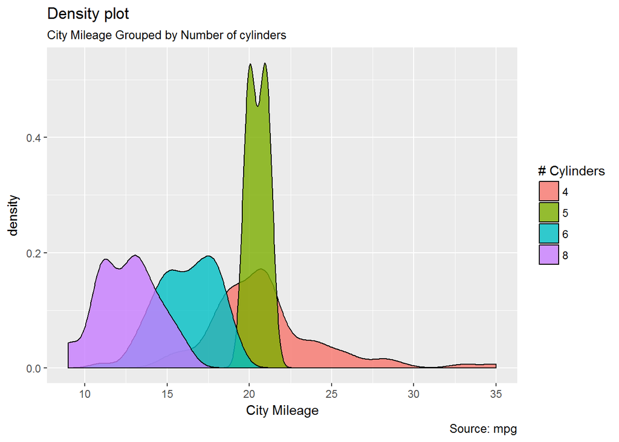

```r
ggplot(mpg, aes(cty)) +
  geom_density(aes(fill=factor(cyl)), alpha=0.8) +
  labs(title="Density plot",
       subtitle="City Mileage Grouped by Number of cylinders",
       caption="Source: mpg",
       x="City Mileage",
       fill="# Cylinders")
```

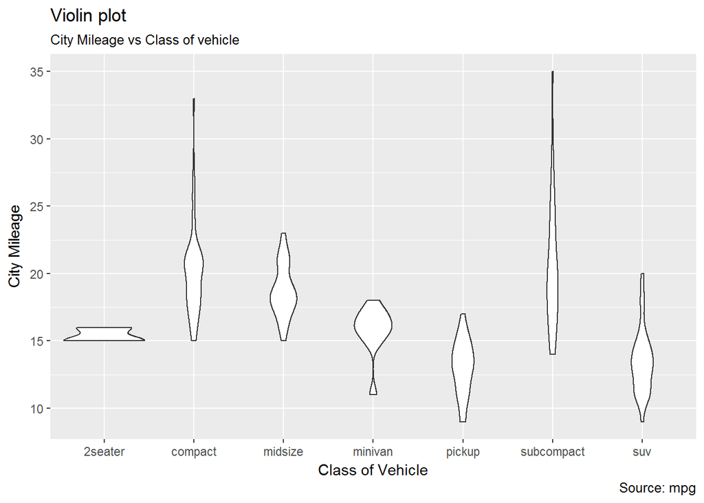

```r
ggplot(mpg, aes(class, cty)) +
  geom_violin() +
  labs(title="Violin plot",
       subtitle="City Mileage vs Class of vehicle",
       caption="Source: mpg",
       x="Class of Vehicle",
       y="City Mileage")
```

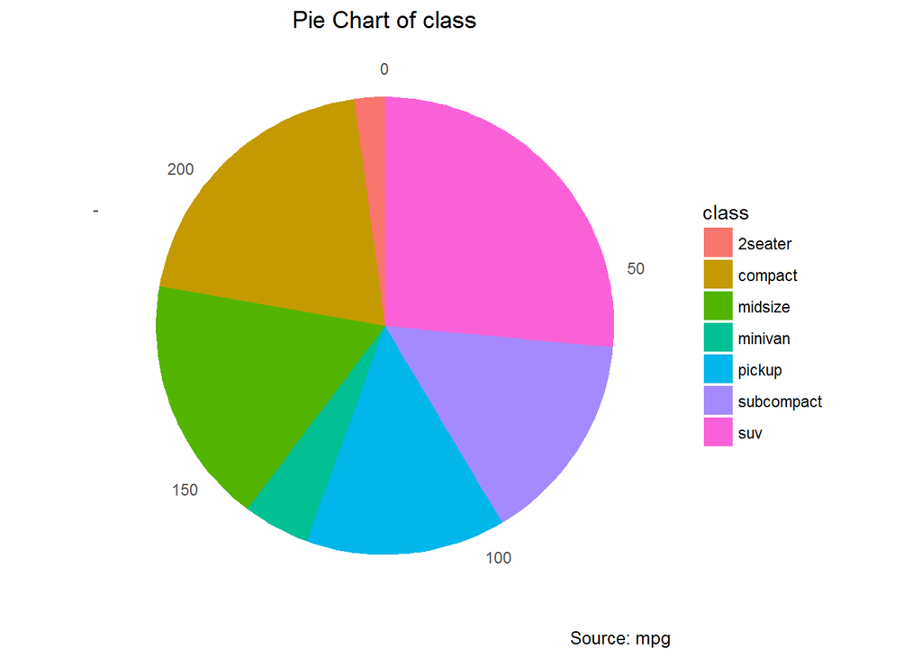

```r
theme_set(theme_classic())
df <- as.data.frame(table(mpg$class))
colnames(df) <- c("class", "freq")
ggplot(df, aes(x = "", y=freq, fill = factor(class))) +
  geom_bar(width = 1, stat = "identity") +
  theme(axis.line = element_blank(),
        plot.title = element_text(hjust=0.5)) +
  labs(fill="class",
       x=NULL,
       y=NULL,
       title="Pie Chart of class",
       caption="Source: mpg") +
  coord_polar(theta = "y", start=0)
```

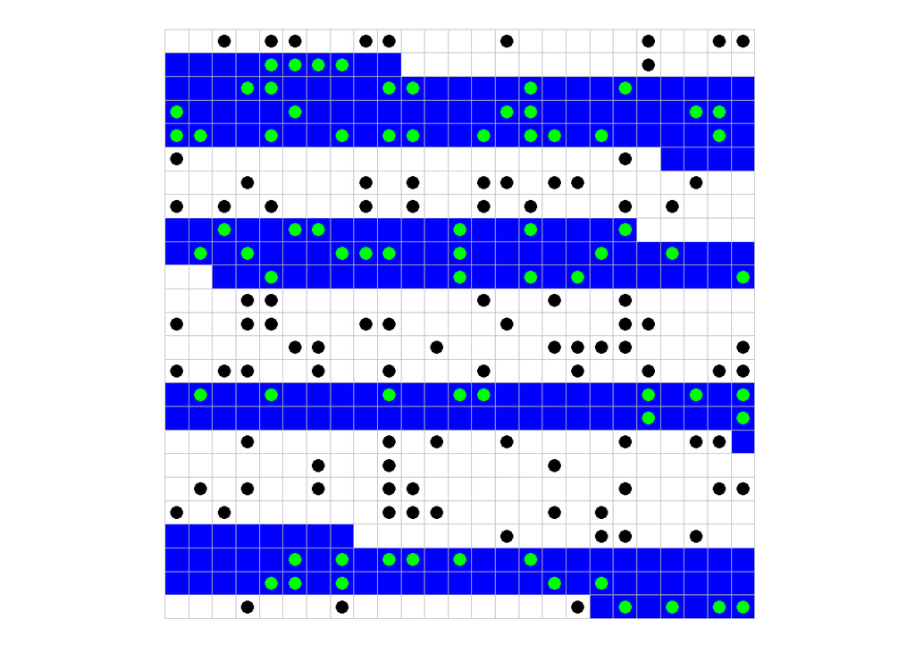

```r
EncSz  <-  25
SynPermCon  <-  0.5
PtPrcnt <- 0.75
SPSmpSz <- round(EncSz^2*PtPrcnt)
ENC <- rep(.3,EncSz^2)
ENC[c(19:83,200:250,353:420,497:585)] <- 1
SPEncBoxes <- tibble(x = rep(c(1:EncSz),EncSz), y = sort(rep(c(1:EncSz),EncSz)))
j <- rep(NA,EncSz^2)
j[sample(EncSz^2,SPSmpSz)] <- rnorm(SPSmpSz,mean=.9*SynPermCon,sd=SynPermCon/5)
j2 <- rep(NA,EncSz^2)
j2[j>0.5] <- 1
j2[j>0.5 & ENC ==1] <- 2
j2[is.na(j)] <- NA
EncAct <- rep(0.1,EncSz^2)
EncAct[j>SynPermCon] <- 1
j <- cut(j,breaks = c(-Inf,seq(0.4,0.6,0.025),Inf))
BlnkGrph = theme(axis.line=element_blank(), axis.text.x=element_blank(), axis.text.y=element_blank(), axis.ticks=element_blank(), axis.title.x=element_blank(),
                 axis.title.y=element_blank(), legend.position="none", panel.background=element_blank(), panel.border=element_blank(), panel.grid.major=element_blank(),
                 panel.grid.minor=element_blank(), plot.background=element_blank(),plot.margin=grid::unit(c(0,0,0,0), "mm"))
SPEncBoxes %>% ggplot(aes(x,y,fill = factor(round(ENC)))) +
  geom_tile(color = "gray",show.legend=FALSE) + BlnkGrph + coord_fixed() +
  geom_point(aes(x,y, color = factor(j2)),shape = 16,na.rm=TRUE, size = 3) +
  scale_fill_manual(values = c("white","blue")) + scale_shape_identity() +
  scale_color_manual(values = c("black","green"))
```

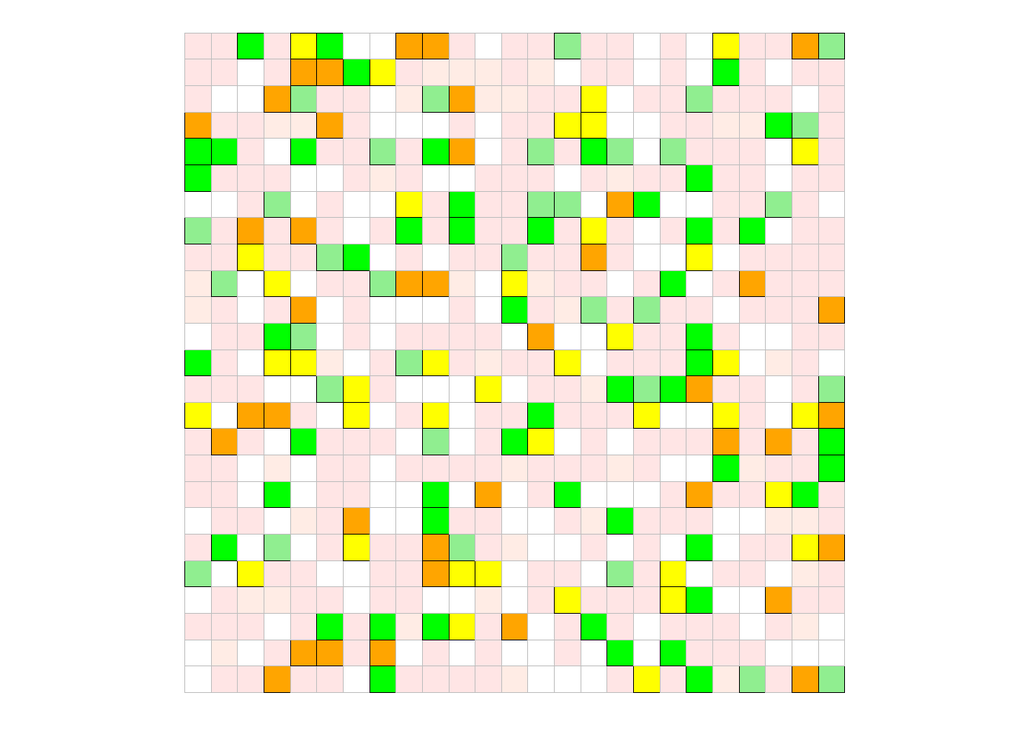

```r
SPEncBoxes %>% ggplot(aes(x,y,fill = j, color = EncAct)) +
  geom_tile(show.legend=FALSE, size = 0.2,alpha=EncAct) + BlnkGrph + coord_fixed() +
  scale_color_gradient(low="gray",high ="black") +
  scale_fill_manual(values = c("red","red","red","red","orangered", "orange","yellow","lightgreen","green1","green1"),na.value="white")
```

## Spend some time playing with ggplot

- See http://ggplot2.tidyverse.org/reference/ for a full list of functions in ggplot
- Here are a list of the datasets built into ggplot (use ?“dataset name” to find out more about the individual datasets)
  - diamonds
    - Prices of 50,000 round cut diamonds
  - economics
    - US economic time series
  - faithfuld
    - 2d density estimate of Old Faithful data
  - midwest
    - Midwest demographics
  - mpg
    - Fuel economy data from 1999 and 2008 for 38 popular models of car
  - msleep
    - An updated and expanded version of the mammals sleep dataset
  - presidential
    - Terms of 11 presidents from Eisenhower to Obama
  - seals
    - Vector field of seal movements
  - txhousing
    - Housing sales in TX
  - luv_colours
    - colors() in Luv space

# SECTION 2 - Data Manipulation

## Basics

### Mathematical and Boolean Operators

```r
-sqrt(25) + (5+3)/4*7 - 2^2
```

```
## [1] 5
```

```r
5%/%3 # Integer Division
```

```
## [1] 1
```

```r
5%%3 # Modulo (remainder after division)
```

```
## [1] 2
```

```r
5 == 6
```

```
## [1] FALSE
```

```r
5 != 6
```

```
## [1] TRUE
```

```r
83 > (25 >= 23)
```

```
## [1] TRUE
```

```r
5 > 3 & 3 < 2
```

```
## [1] FALSE
```

```r
5 > 3 | 3 < 2
```

```
## [1] TRUE
```

### Vectors and Sequences

```r
1:4
```

```
## [1] 1 2 3 4
```

```r
c(5,3,2,1) # Creates a vector via concaternation (hence the c)
```

```
## [1] 5 3 2 1
```

```r
c(12,1:4,6)
```

```
## [1] 12  1  2  3  4  6
```

```r
seq(from = 1, t= 10, by = 2) # Creates a vector with the given paramters
```

```
## [1] 1 3 5 7 9
```

```r
seq(1,10,2) # creates the same vector without naming the paramters
```

```
## [1] 1 3 5 7 9
```

```r
seq(1,10) # R uses the default values for any empty parameters
```

```
##  [1]  1  2  3  4  5  6  7  8  9 10
```

```r
seq(to = 10, by = 2)
```

```
## [1] 1 3 5 7 9
```

```r
seq(by = 2, to = 10)
```

```
## [1] 1 3 5 7 9
```

```r
c(seq(1,10,2), 25, 10)
```

```
## [1]  1  3  5  7  9 25 10
```

```r
c(seq(1,10,2), 25, 10) > 12
```

```
## [1] FALSE FALSE FALSE FALSE FALSE  TRUE FALSE
```

```r
c(seq(1,10,2), 25, 10) * 2
```

```
## [1]  2  6 10 14 18 50 20
```

### Variables and Assignment

```r
x = 5+3
(x = 5+3)
```

```
## [1] 8
```

```r
x <- 5+3
(x <- 5+3)
```

```
## [1] 8
```

```r
y <- x
y
```

```
## [1] 8
```

```r
x <- 5+3 > 2
x
```

```
## [1] TRUE
```

```r
x <- seq(172,23,-13)
x
```

```
##  [1] 172 159 146 133 120 107  94  81  68  55  42  29
```

### Indexing

#### R starts at 1

```r
x <- seq(172,23,-13)
x[1]
```

```
## [1] 172
```

```r
x[c(1,3)]
```

```
## [1] 172 146
```

```r
x[2:4]
```

```
## [1] 159 146 133
```

```r
x[4:2]
```

```
## [1] 133 146 159
```

```r
x[]
```

```
##  [1] 172 159 146 133 120 107  94  81  68  55  42  29
```

```r
x[-1]
```

```
##  [1] 159 146 133 120 107  94  81  68  55  42  29
```

```r
x[-c(1,3)]
```

```
##  [1] 159 133 120 107  94  81  68  55  42  29
```

```r
x[x%%2==0]
```

```
## [1] 172 146 120  94  68  42
```

```r
y <- x[x%%2==0]
y[9] <- 10
y
```

```
## [1] 172 146 120  94  68  42  NA  NA  10
```

### Built in Functions

```r
x <-  1:20
mean(x)
```

```
## [1] 10.5
```

```r
max(x)
```

```
## [1] 20
```

```r
min(x)
```

```
## [1] 1
```

```r
length(x)
```

```
## [1] 20
```

```r
range(x)
```

```
## [1]  1 20
```

```r
prod(x)
```

```
## [1] 2.432902e+18
```

```r
var(x)
```

```
## [1] 35
```

```r
log(x)
```

```
##  [1] 0.0000000 0.6931472 1.0986123 1.3862944 1.6094379 1.7917595 1.9459101
##  [8] 2.0794415 2.1972246 2.3025851 2.3978953 2.4849066 2.5649494 2.6390573
## [15] 2.7080502 2.7725887 2.8332133 2.8903718 2.9444390 2.9957323
```

```r
sqrt(x)
```

```
##  [1] 1.000000 1.414214 1.732051 2.000000 2.236068 2.449490 2.645751
##  [8] 2.828427 3.000000 3.162278 3.316625 3.464102 3.605551 3.741657
## [15] 3.872983 4.000000 4.123106 4.242641 4.358899 4.472136
```

### Exercises

1. Create a vector of 2 through 8 squared:  
   4, 9, 16, 25, 36, 49, 64
2. Create a vector of the square roots of the sum of sqaures of every pair of digits of 1 to 100:  
   sqrt(1^2 + 2^2), sqrt(3^2 + 4^2), sqrt(5^2 + 6^2), … , sqrt(99^2 + 100^2)
3. Create a vector of the numbers 1 to 100 not divisible by 3 or 5:  
   1, 2, 4, 7, 8, 11, 13, 14, 16, 17, … , 97, 98

## Trouble with Tibbles

[figure not shown]

- Tibbles are a type of data frame (way of representing data) that are lazy (they don’t change variable names or types) and surly (e.g., they complain when a variable does not exist)
- Tibbles differ from traidtional data frames in two key ways, printing and subsetting

```r
iris
```

```
##     Sepal.Length Sepal.Width Petal.Length Petal.Width    Species
## 1            5.1         3.5          1.4         0.2     setosa
## 2            4.9         3.0          1.4         0.2     setosa
## 3            4.7         3.2          1.3         0.2     setosa
## 4            4.6         3.1          1.5         0.2     setosa
## 5            5.0         3.6          1.4         0.2     setosa
## 6            5.4         3.9          1.7         0.4     setosa
## 7            4.6         3.4          1.4         0.3     setosa
## 8            5.0         3.4          1.5         0.2     setosa
## 9            4.4         2.9          1.4         0.2     setosa
## 10           4.9         3.1          1.5         0.1     setosa
## 11           5.4         3.7          1.5         0.2     setosa
## 12           4.8         3.4          1.6         0.2     setosa
## 13           4.8         3.0          1.4         0.1     setosa
## 14           4.3         3.0          1.1         0.1     setosa
```

[output cut: 136 more lines]

```r
as_tibble(iris) # shows only a few rows as well as the type of data in each row
```

```
## # A tibble: 150 x 5
##    Sepal.Length Sepal.Width Petal.Length Petal.Width Species
##           <dbl>       <dbl>        <dbl>       <dbl>  <fctr>
##  1          5.1         3.5          1.4         0.2  setosa
##  2          4.9         3.0          1.4         0.2  setosa
##  3          4.7         3.2          1.3         0.2  setosa
##  4          4.6         3.1          1.5         0.2  setosa
##  5          5.0         3.6          1.4         0.2  setosa
##  6          5.4         3.9          1.7         0.4  setosa
##  7          4.6         3.4          1.4         0.3  setosa
##  8          5.0         3.4          1.5         0.2  setosa
##  9          4.4         2.9          1.4         0.2  setosa
## 10          4.9         3.1          1.5         0.1  setosa
## # ... with 140 more rows
```

##### Partial Matching

```r
iris$Spec
```

```
##   [1] setosa     setosa     setosa     setosa     setosa     setosa
##   [7] setosa     setosa     setosa     setosa     setosa     setosa
##  [13] setosa     setosa     setosa     setosa     setosa     setosa
##  [19] setosa     setosa     setosa     setosa     setosa     setosa
##  [25] setosa     setosa     setosa     setosa     setosa     setosa
##  [31] setosa     setosa     setosa     setosa     setosa     setosa
##  [37] setosa     setosa     setosa     setosa     setosa     setosa
##  [43] setosa     setosa     setosa     setosa     setosa     setosa
##  [49] setosa     setosa     versicolor versicolor versicolor versicolor
##  [55] versicolor versicolor versicolor versicolor versicolor versicolor
##  [61] versicolor versicolor versicolor versicolor versicolor versicolor
##  [67] versicolor versicolor versicolor versicolor versicolor versicolor
##  [73] versicolor versicolor versicolor versicolor versicolor versicolor
##  [79] versicolor versicolor versicolor versicolor versicolor versicolor
##  [85] versicolor versicolor versicolor versicolor versicolor versicolor
##  [91] versicolor versicolor versicolor versicolor versicolor versicolor
##  [97] versicolor versicolor versicolor versicolor virginica  virginica
## [103] virginica  virginica  virginica  virginica  virginica  virginica
## [109] virginica  virginica  virginica  virginica  virginica  virginica
## [115] virginica  virginica  virginica  virginica  virginica  virginica
## [121] virginica  virginica  virginica  virginica  virginica  virginica
## [127] virginica  virginica  virginica  virginica  virginica  virginica
## [133] virginica  virginica  virginica  virginica  virginica  virginica
## [139] virginica  virginica  virginica  virginica  virginica  virginica
## [145] virginica  virginica  virginica  virginica  virginica  virginica
## Levels: setosa versicolor virginica
```

```r
as_tibble(iris)$Spec
```

[output not shown]

##### Subsetting

```r
iris[1]
```

```
##     Sepal.Length
## 1            5.1
## 2            4.9
## 3            4.7
## 4            4.6
## 5            5.0
## 6            5.4
## 7            4.6
## 8            5.0
## 9            4.4
## 10           4.9
## 11           5.4
## 12           4.8
## 13           4.8
## 14           4.3
```

[output cut: 136 more lines]

```r
iris[,1]
```

```
##   [1] 5.1 4.9 4.7 4.6 5.0 5.4 4.6 5.0 4.4 4.9 5.4 4.8 4.8 4.3 5.8 5.7 5.4
##  [18] 5.1 5.7 5.1 5.4 5.1 4.6 5.1 4.8 5.0 5.0 5.2 5.2 4.7 4.8 5.4 5.2 5.5
##  [35] 4.9 5.0 5.5 4.9 4.4 5.1 5.0 4.5 4.4 5.0 5.1 4.8 5.1 4.6 5.3 5.0 7.0
##  [52] 6.4 6.9 5.5 6.5 5.7 6.3 4.9 6.6 5.2 5.0 5.9 6.0 6.1 5.6 6.7 5.6 5.8
##  [69] 6.2 5.6 5.9 6.1 6.3 6.1 6.4 6.6 6.8 6.7 6.0 5.7 5.5 5.5 5.8 6.0 5.4
##  [86] 6.0 6.7 6.3 5.6 5.5 5.5 6.1 5.8 5.0 5.6 5.7 5.7 6.2 5.1 5.7 6.3 5.8
## [103] 7.1 6.3 6.5 7.6 4.9 7.3 6.7 7.2 6.5 6.4 6.8 5.7 5.8 6.4 6.5 7.7 7.7
## [120] 6.0 6.9 5.6 7.7 6.3 6.7 7.2 6.2 6.1 6.4 7.2 7.4 7.9 6.4 6.3 6.1 7.7
## [137] 6.3 6.4 6.0 6.9 6.7 6.9 5.8 6.8 6.7 6.7 6.3 6.5 6.2 5.9
```

```r
as_tibble(iris)[1]
```

```
## # A tibble: 150 x 1
##    Sepal.Length
##           <dbl>
##  1          5.1
##  2          4.9
##  3          4.7
##  4          4.6
##  5          5.0
##  6          5.4
##  7          4.6
##  8          5.0
##  9          4.4
## 10          4.9
## # ... with 140 more rows
```

```r
as_tibble(iris)[,1]
```

```
## # A tibble: 150 x 1
##    Sepal.Length
##           <dbl>
##  1          5.1
##  2          4.9
##  3          4.7
##  4          4.6
##  5          5.0
##  6          5.4
##  7          4.6
##  8          5.0
##  9          4.4
## 10          4.9
## # ... with 140 more rows
```

```r
as_tibble(iris)[[1]]
```

```
##   [1] 5.1 4.9 4.7 4.6 5.0 5.4 4.6 5.0 4.4 4.9 5.4 4.8 4.8 4.3 5.8 5.7 5.4
##  [18] 5.1 5.7 5.1 5.4 5.1 4.6 5.1 4.8 5.0 5.0 5.2 5.2 4.7 4.8 5.4 5.2 5.5
##  [35] 4.9 5.0 5.5 4.9 4.4 5.1 5.0 4.5 4.4 5.0 5.1 4.8 5.1 4.6 5.3 5.0 7.0
##  [52] 6.4 6.9 5.5 6.5 5.7 6.3 4.9 6.6 5.2 5.0 5.9 6.0 6.1 5.6 6.7 5.6 5.8
##  [69] 6.2 5.6 5.9 6.1 6.3 6.1 6.4 6.6 6.8 6.7 6.0 5.7 5.5 5.5 5.8 6.0 5.4
##  [86] 6.0 6.7 6.3 5.6 5.5 5.5 6.1 5.8 5.0 5.6 5.7 5.7 6.2 5.1 5.7 6.3 5.8
## [103] 7.1 6.3 6.5 7.6 4.9 7.3 6.7 7.2 6.5 6.4 6.8 5.7 5.8 6.4 6.5 7.7 7.7
## [120] 6.0 6.9 5.6 7.7 6.3 6.7 7.2 6.2 6.1 6.4 7.2 7.4 7.9 6.4 6.3 6.1 7.7
## [137] 6.3 6.4 6.0 6.9 6.7 6.9 5.8 6.8 6.7 6.7 6.3 6.5 6.2 5.9
```

`install.packages("nycflights13")`  
`library(nycflights13)`

```r
library(nycflights13)
flights # On-time data for all flights that departed NYC (i.e. JFK, LGA or EWR) in 2013
```

```
## # A tibble: 336,776 x 19
##     year month   day dep_time sched_dep_time dep_delay arr_time
##    <int> <int> <int>    <int>          <int>     <dbl>    <int>
##  1  2013     1     1      517            515         2      830
##  2  2013     1     1      533            529         4      850
##  3  2013     1     1      542            540         2      923
##  4  2013     1     1      544            545        -1     1004
##  5  2013     1     1      554            600        -6      812
##  6  2013     1     1      554            558        -4      740
##  7  2013     1     1      555            600        -5      913
##  8  2013     1     1      557            600        -3      709
##  9  2013     1     1      557            600        -3      838
## 10  2013     1     1      558            600        -2      753
## # ... with 336,766 more rows, and 12 more variables: sched_arr_time <int>,
## #   arr_delay <dbl>, carrier <chr>, flight <int>, tailnum <chr>,
## #   origin <chr>, dest <chr>, air_time <dbl>, distance <dbl>, hour <dbl>,
## #   minute <dbl>, time_hour <dttm>
```

```r
summary(flights)
```

```
##       year          month             day           dep_time
##  Min.   :2013   Min.   : 1.000   Min.   : 1.00   Min.   :   1
##  1st Qu.:2013   1st Qu.: 4.000   1st Qu.: 8.00   1st Qu.: 907
##  Median :2013   Median : 7.000   Median :16.00   Median :1401
##  Mean   :2013   Mean   : 6.549   Mean   :15.71   Mean   :1349
##  3rd Qu.:2013   3rd Qu.:10.000   3rd Qu.:23.00   3rd Qu.:1744
##  Max.   :2013   Max.   :12.000   Max.   :31.00   Max.   :2400
##                                                  NA's   :8255
##  sched_dep_time   dep_delay          arr_time    sched_arr_time
##  Min.   : 106   Min.   : -43.00   Min.   :   1   Min.   :   1
##  1st Qu.: 906   1st Qu.:  -5.00   1st Qu.:1104   1st Qu.:1124
##  Median :1359   Median :  -2.00   Median :1535   Median :1556
##  Mean   :1344   Mean   :  12.64   Mean   :1502   Mean   :1536
##  3rd Qu.:1729   3rd Qu.:  11.00   3rd Qu.:1940   3rd Qu.:1945
##  Max.   :2359   Max.   :1301.00   Max.   :2400   Max.   :2359
##                 NA's   :8255      NA's   :8713
##    arr_delay          carrier              flight       tailnum
##  Min.   : -86.000   Length:336776      Min.   :   1   Length:336776
##  1st Qu.: -17.000   Class :character   1st Qu.: 553   Class :character
##  Median :  -5.000   Mode  :character   Median :1496   Mode  :character
##  Mean   :   6.895                      Mean   :1972
##  3rd Qu.:  14.000                      3rd Qu.:3465
##  Max.   :1272.000                      Max.   :8500
##  NA's   :9430
##     origin              dest              air_time        distance
##  Length:336776      Length:336776      Min.   : 20.0   Min.   :  17
##  Class :character   Class :character   1st Qu.: 82.0   1st Qu.: 502
##  Mode  :character   Mode  :character   Median :129.0   Median : 872
##                                        Mean   :150.7   Mean   :1040
##                                        3rd Qu.:192.0   3rd Qu.:1389
##                                        Max.   :695.0   Max.   :4983
##                                        NA's   :9430
##       hour           minute        time_hour
##  Min.   : 1.00   Min.   : 0.00   Min.   :2013-01-01 05:00:00
##  1st Qu.: 9.00   1st Qu.: 8.00   1st Qu.:2013-04-04 13:00:00
##  Median :13.00   Median :29.00   Median :2013-07-03 10:00:00
##  Mean   :13.18   Mean   :26.23   Mean   :2013-07-03 05:02:36
##  3rd Qu.:17.00   3rd Qu.:44.00   3rd Qu.:2013-10-01 07:00:00
##  Max.   :23.00   Max.   :59.00   Max.   :2013-12-31 23:00:00
##
```

##### Data Types

- `int` integers
- `dbl` doubles or real numbers
- `chr` character vectors (strings)
- `dttm` date-time
- `date` date
- `lgl` logical (TRUE or FALSE)
- `fctr` factors (catgeorical variables with fixed possible values, e.g., dropdown list)

```r
flights[c("dep_time","tailnum","air_time","time_hour")]
```

```
## # A tibble: 336,776 x 4
##    dep_time tailnum air_time           time_hour
##       <int>   <chr>    <dbl>              <dttm>
##  1      517  N14228      227 2013-01-01 05:00:00
##  2      533  N24211      227 2013-01-01 05:00:00
##  3      542  N619AA      160 2013-01-01 05:00:00
##  4      544  N804JB      183 2013-01-01 05:00:00
##  5      554  N668DN      116 2013-01-01 06:00:00
##  6      554  N39463      150 2013-01-01 05:00:00
##  7      555  N516JB      158 2013-01-01 06:00:00
##  8      557  N829AS       53 2013-01-01 06:00:00
##  9      557  N593JB      140 2013-01-01 06:00:00
## 10      558  N3ALAA      138 2013-01-01 06:00:00
## # ... with 336,766 more rows
```

# SECTION 3 -